# [M1 MIASHS - TER] Visualisation du dataset TOUA

## Introduction

La première étape de notre projet de TER consiste à analyser trois jeux de données sur des arabidopsis pour comprendre comment des conditions de fort CO2 impactent la quantité de nutriments qu’elles produisent. Vous trouverez ci-après l’analyse du premier dataset dont nous disposons qui s’appelle TOUA.

## Ouverture du csv

```r
toua <- read.csv2("TOUA_phenotypes.csv")
head(toua)
```

```
##   genotype Cu_eCo2 Cu_aCo2 Fe_eCo2 Fe_aCo2 Mg_eCo2 Mg_aCo2 Mn_eCo2 Mn_aCo2
## 1      1_2    5.93    7.74   56.61   87.01 2877.45 2758.60   48.45   41.91
## 2      1_3    6.92    7.91   73.42   62.29 2782.73 2992.24   50.18   45.19
## 3      1_4    7.78    8.05   68.88   82.91 3083.72 2975.63   48.33   41.94
## 4      1_6    9.34    8.47   81.39   85.88 2975.47 2914.94   57.24   40.64
## 5      1_7    7.99    8.42   76.48   86.71 2854.02 2882.91   49.52   48.48
## 6      1_8    7.07    9.07   69.73   85.97 2973.51 2939.51   47.58   51.47
##   Na_eCo2 Na_aCo2 Zn_eCo2 Zn_aCo2 C_eCo2 C_aCo2 N_eCo2 N_aCo2 N_change
## 1  961.87  852.11   26.20   35.76  27.67  38.37   3.73   6.37    -41.5
## 2  886.46  942.78   30.65   38.55  40.96  39.88   5.27   6.31    -16.4
## 3  685.74  643.56   37.77   44.87  37.96  37.05   5.75   6.43    -10.7
## 4  683.63  687.55   38.16   46.69  37.95  38.35   5.76   6.65    -13.4
## 5  659.94  641.13   37.54   44.84  41.37  38.71   5.38   6.55    -17.9
## 6  687.61  660.59   37.93   52.65  38.17  39.68   5.69   6.42    -11.3
##   aCN_ratio eCN_ratio eCN_aCN Fe_change Mg_change Mn_change Na_change Zn_change
## 1      6.03      7.42    23.2    -34.94      4.31     15.61     12.88    -26.73
## 2      6.32      7.77    22.9     17.86     -7.00     11.06     -5.97    -20.48
## 3      5.76      6.61    14.7    -16.93      3.63     15.21      6.55    -15.82
## 4      5.77      6.59    14.3     -5.23      2.08     40.84     -0.57    -18.27
## 5      5.91      7.70    30.2    -11.80     -1.00      2.15      2.93    -16.27
## 6      6.18      6.71     8.4    -18.90      1.16     -7.54      4.09    -27.97
```

## Rajout de la colonne de Changement pour le Carbonne

```r
toua$C_change <- round(((toua$C_eCo2-toua$C_aCo2)/toua$C_aCo2)*100, digits = 2)
toua$Cu_change <- round(((toua$Cu_eCo2-toua$Cu_aCo2)/toua$Cu_aCo2)*100, digits = 2)
toua_ch <- select(toua,"genotype"|contains("change"))
```

## Passage en format long avec gather

```r
toua_chl <- gather(data = toua_ch, key = "element", value = "valeur", 2:9)
head(toua_chl)
```

```
##   genotype  element valeur
## 1      1_2 N_change  -41.5
## 2      1_3 N_change  -16.4
## 3      1_4 N_change  -10.7
## 4      1_6 N_change  -13.4
## 5      1_7 N_change  -17.9
## 6      1_8 N_change  -11.3
```

```r
#unique(toua_chl$element)
```

## Identification des outliers

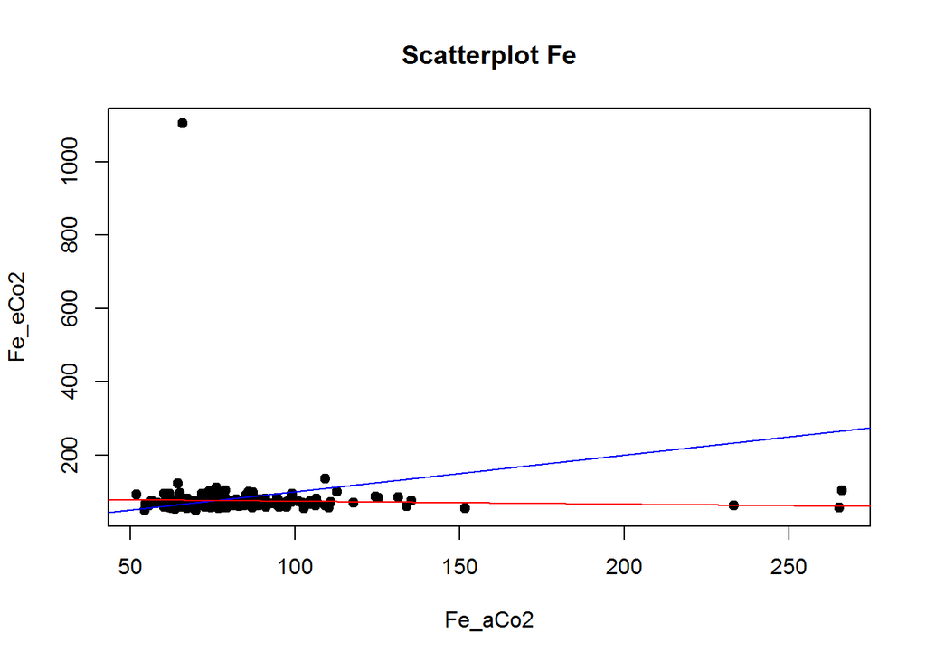

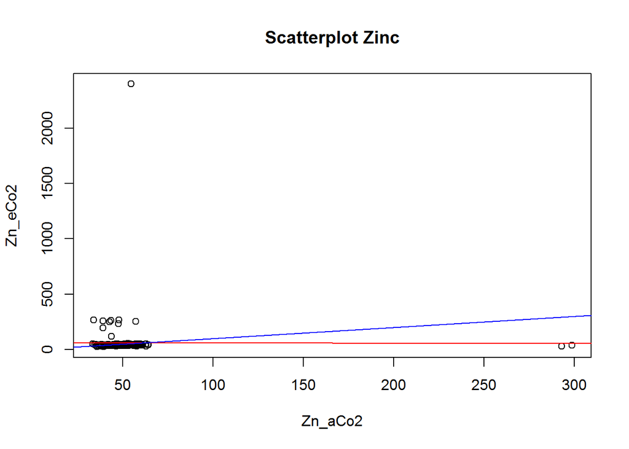

Comme le montrent ces deux Scatter plots,certaines valeurs pour certains éléments sont très singulières, et après discussion avec nos encadrants nous en avons conclu qu’il s’agit d’erreurs de mesures qui ne peuvent pas exister en réalité. Nous allons donc les supprimer.

## Suppression des outliers

```r
toua_no_out <- toua
k= 3
for (i in 2:17) {
  binf <- median(toua[,i]) - k* mad(toua[,i])
  bsup <- median(toua[,i]) + k* mad(toua[,i])
  outlier_idx <- which(toua_no_out[,i] < binf | toua_no_out[,i] > bsup)
    if (length(outlier_idx) == 0) {
      toua_no_out = toua_no_out
    }
    else{
      toua_no_out = toua_no_out[-c(outlier_idx),]
      }
  print(outlier_idx)
  }
```

```
## [1]  29  78 131
##  [1]  11  34  60 104 105 107 108 109 110 111 112 113 114 115 116 118 119 120 121
## [20] 122
##  [1]  79  80  83  84  94 100 116 124 127 128 131 155 157
## [1]  34  42  96 126
## [1] 141
## integer(0)
## [1] 92
## integer(0)
## [1]  16  53 104
## [1] 134 138
## [1] 101 102 103 104 105 106 107
## [1] 29 32
## [1]   1 103
## [1] 47 88
## integer(0)
## integer(0)
```

## Première Visualisation : Variation moyenne des mesures entre le aCO2 et le eCO2

Nous avons ici voulu reproduire une visualisation qui avait été faite dans le cas du riz pour montrer la variation de chaque élément quand la plante est en condition de fort CO2 et quand elle est en condition de CO2 ambiant

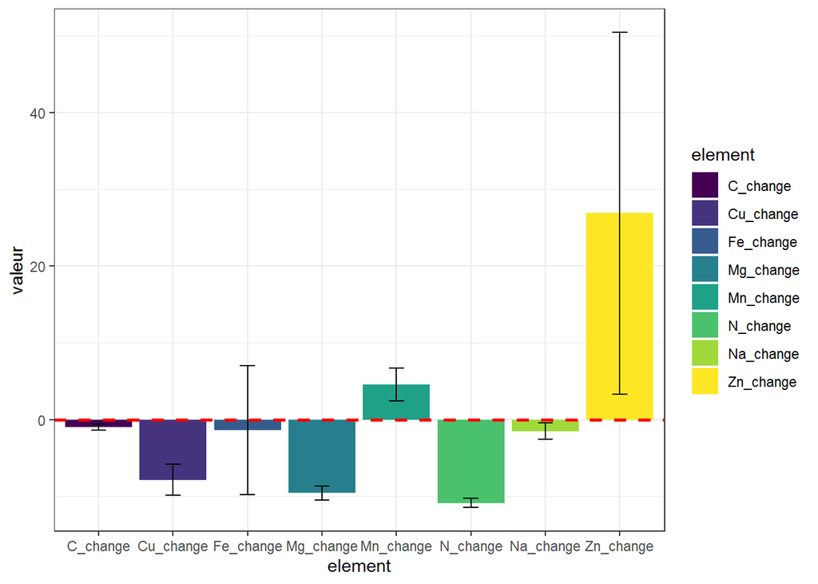

```r
ggplot(toua_chl, aes(element, valeur, fill = element))+
  stat_summary(fun = mean, geom = "bar") +
  stat_summary(fun.data = mean_se, geom = "errorbar", width = 0.2)+
  geom_hline(yintercept = 0, color = "red", linetype = "dashed", size = 1) +
  scale_fill_viridis_d() +
  scale_color_viridis_d() +
  theme_bw()
```

Observations :

1. On n’observe pas vraiment de hausse des taux de Carbonne mesurés (contrairement à ce qui a été vu chez le riz par exemple)
2. On n’observe pas une diminution drastique de la concentration dans les autres élements
3. Les écarts type suggèrent une forte variabilité dans la population

Nous voudrions avoir une meilleure idée de la distribution des valeurs mesurés pour chaque élement donc faisons un violin plot

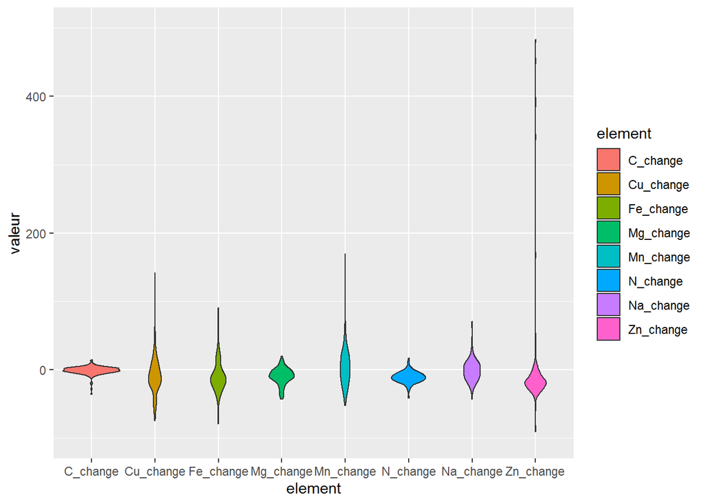

## Scatter Plot Ratios eCN/aCN

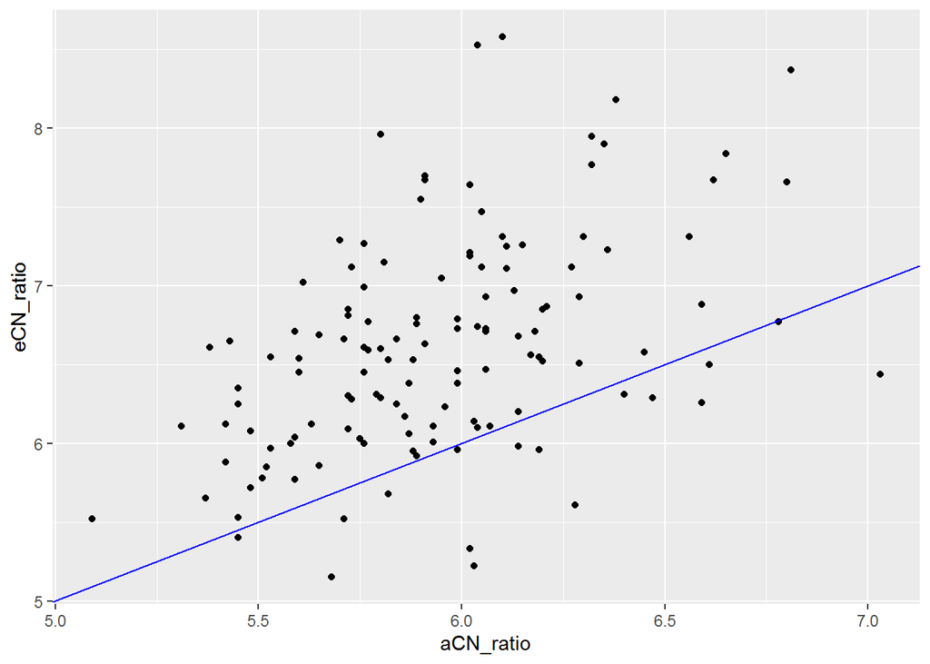

### Scatter Plots des éléments e/a

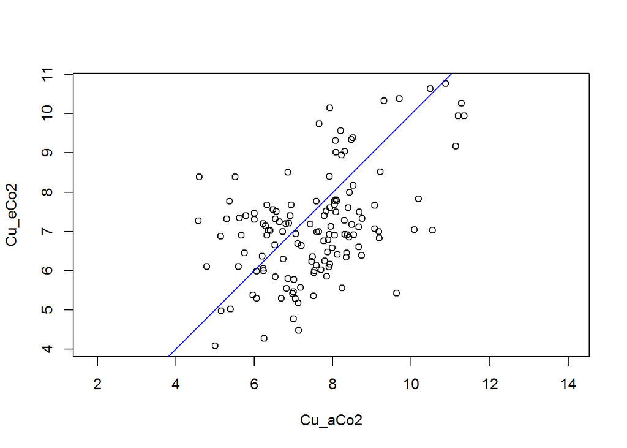

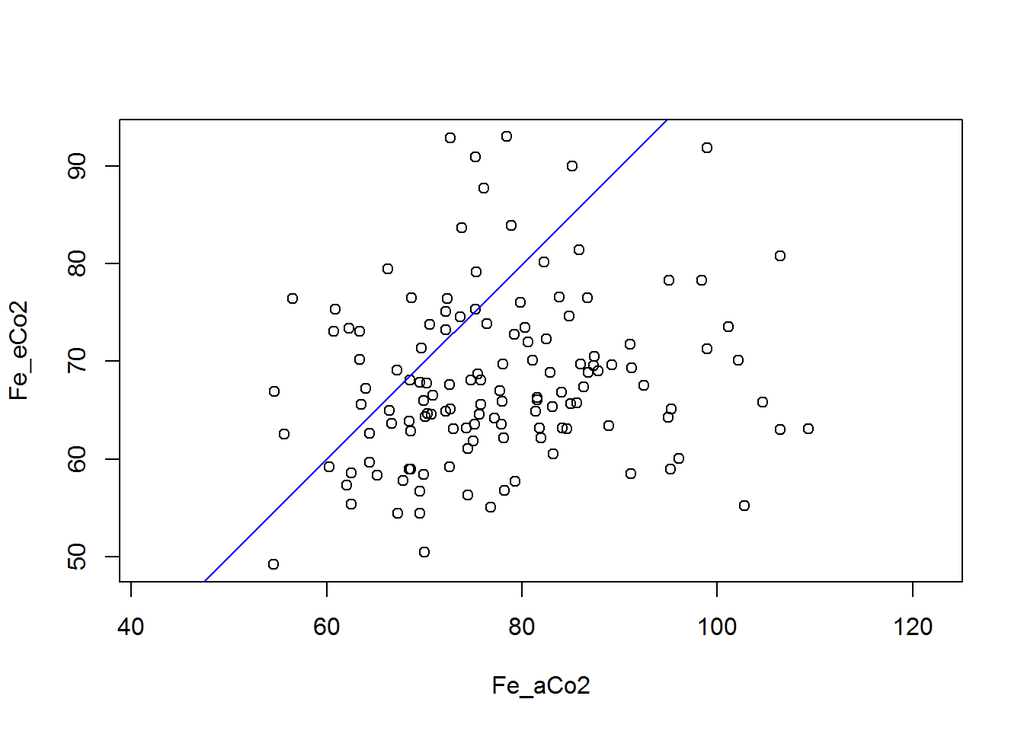

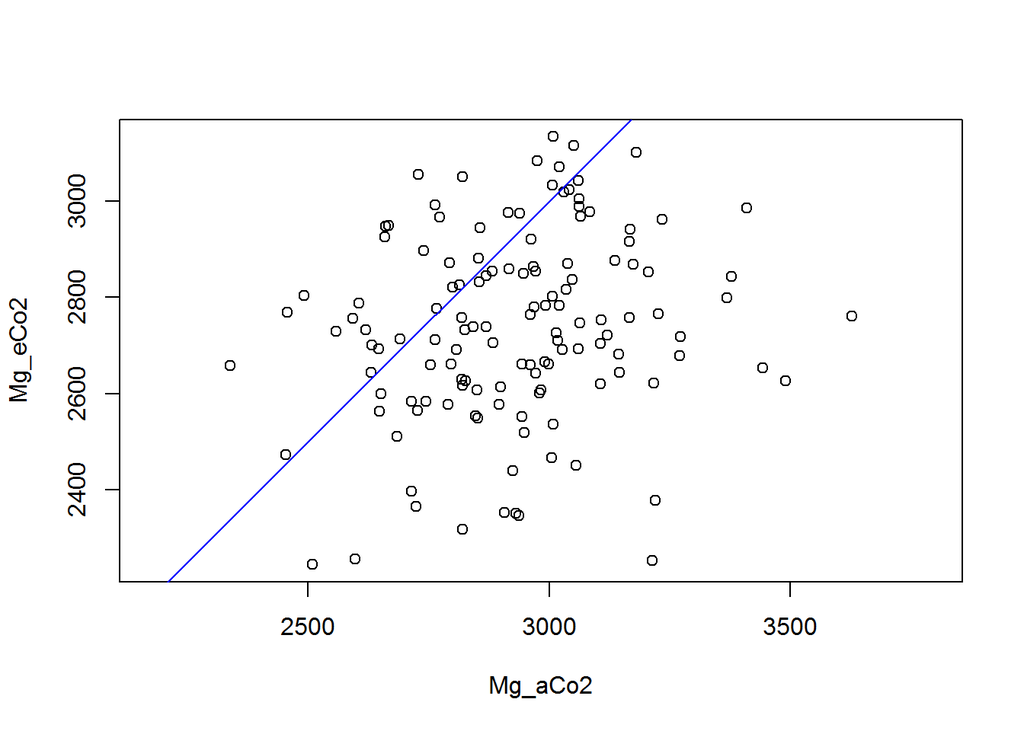

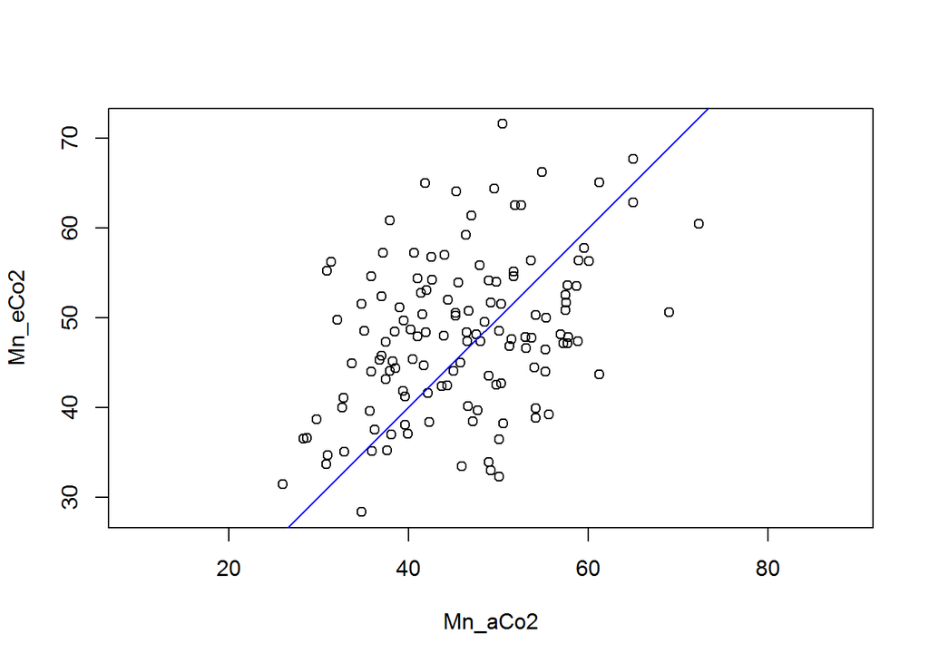

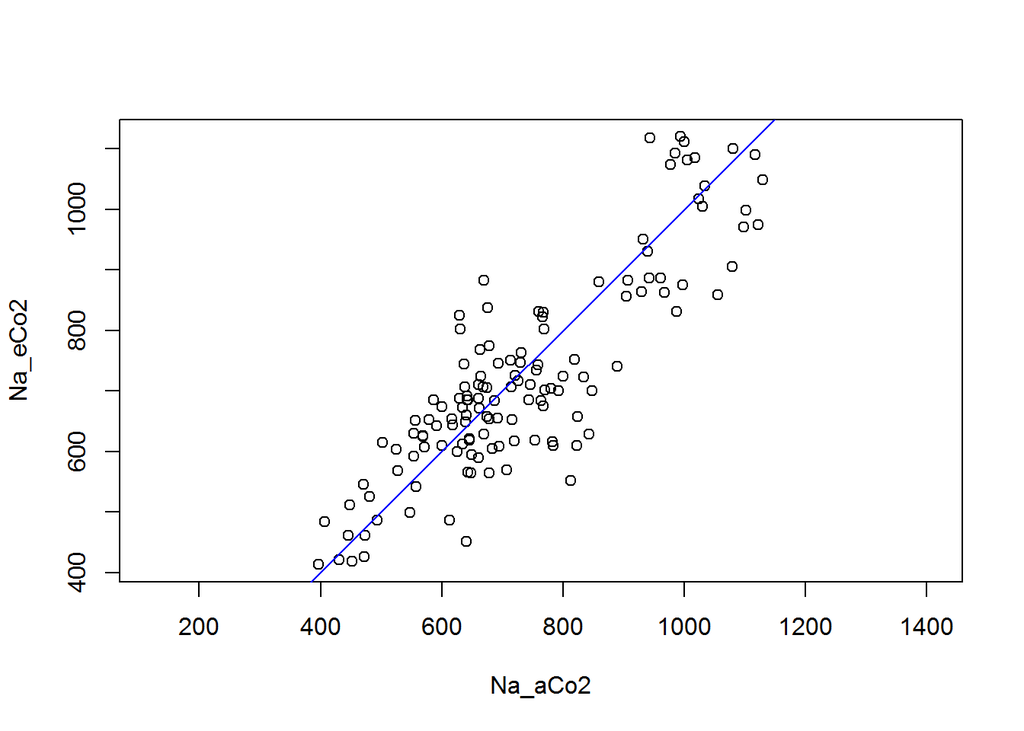

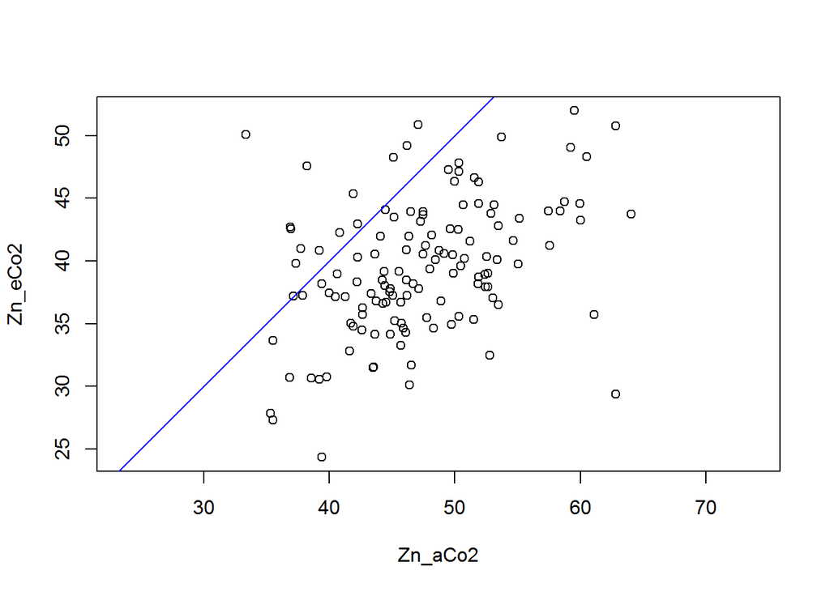

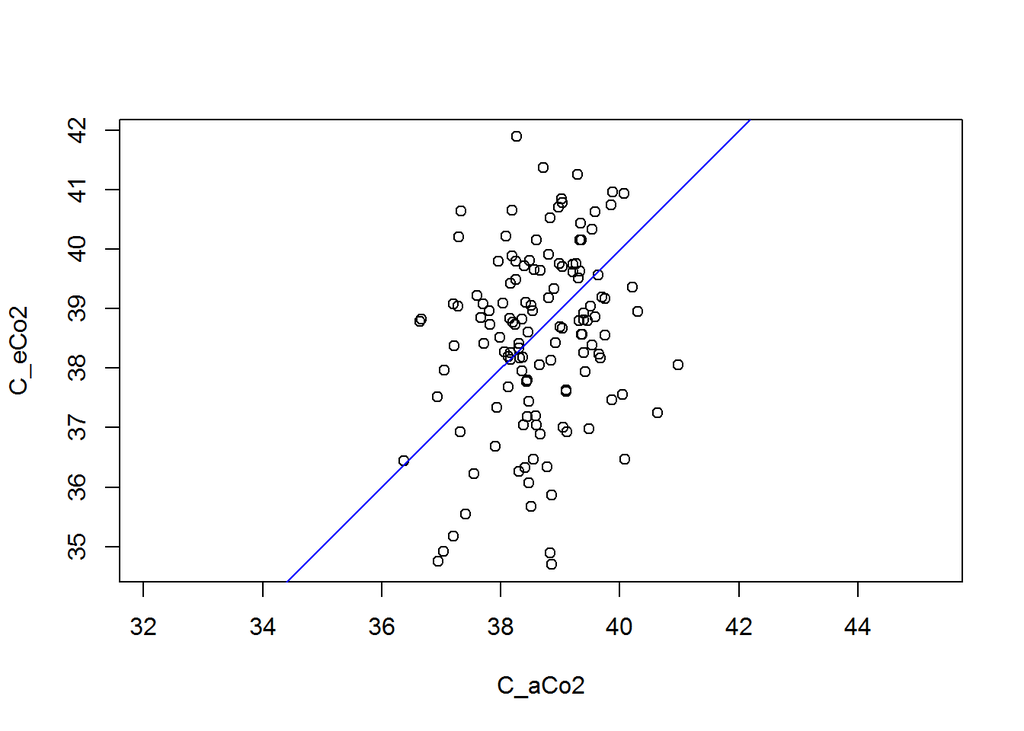

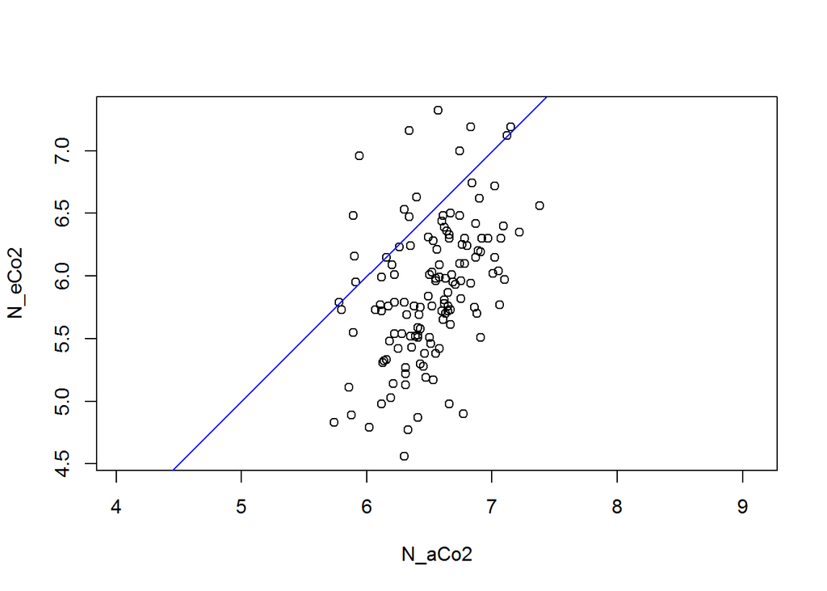

```r
i = 2
while (i < 17) {
plot(toua_no_out[,i+1], toua_no_out[,i], xlab = names(toua_no_out[i+1]), ylab = names(toua_no_out[i]),asp=1)
abline(0,1, col = "blue")
i = i + 2}
```

## Tests de normalité : Test de Shapiro

Dans le but de choisir des tests sur la moyenne et sur la variance adaptés à nos données, nous avons commencé par réaliser un test de normalité, ici le test de Shapiro.

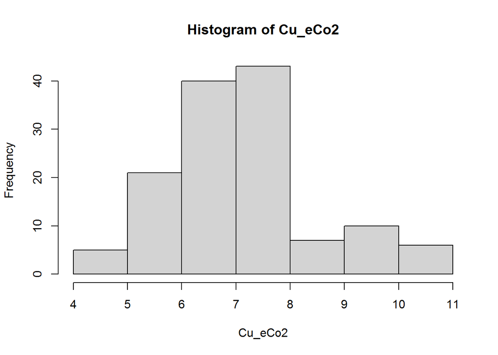

```
## [1] "Test de Shapiro pour la donnée Cu_eCo2"
##
##  Shapiro-Wilk normality test
##
## data:  toua_no_out[, i]
## W = 0.96086, p-value = 0.0007664
```

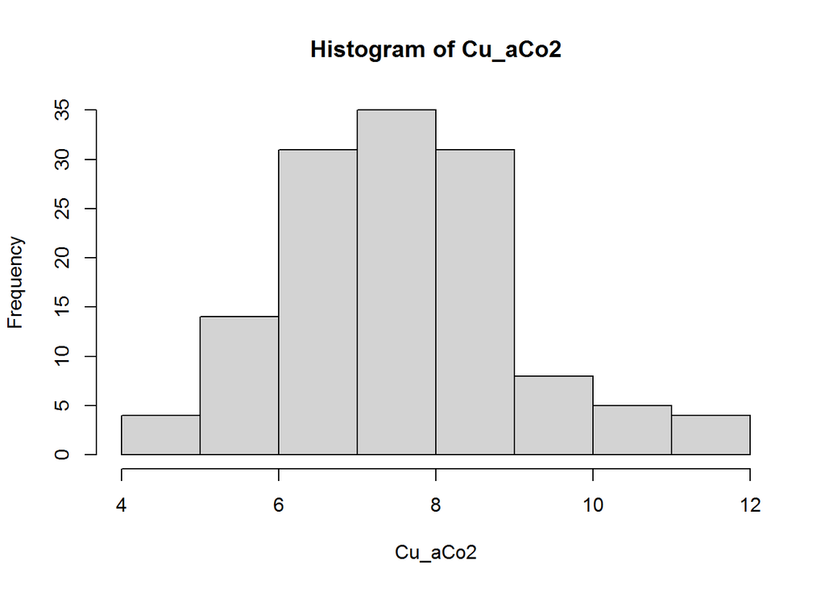

```
## [1] "Test de Shapiro pour la donnée Cu_aCo2"
##
##  Shapiro-Wilk normality test
##
## data:  toua_no_out[, i]
## W = 0.9758, p-value = 0.01851
```

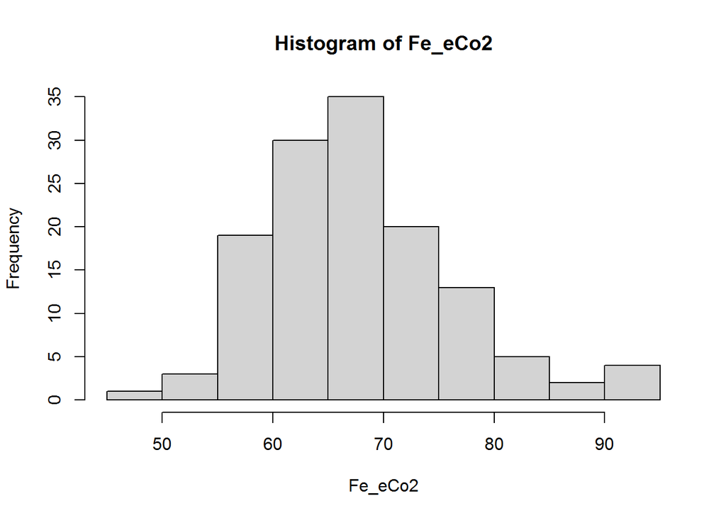

```
## [1] "Test de Shapiro pour la donnée Fe_eCo2"
##
##  Shapiro-Wilk normality test
##
## data:  toua_no_out[, i]
## W = 0.95996, p-value = 0.000642
```

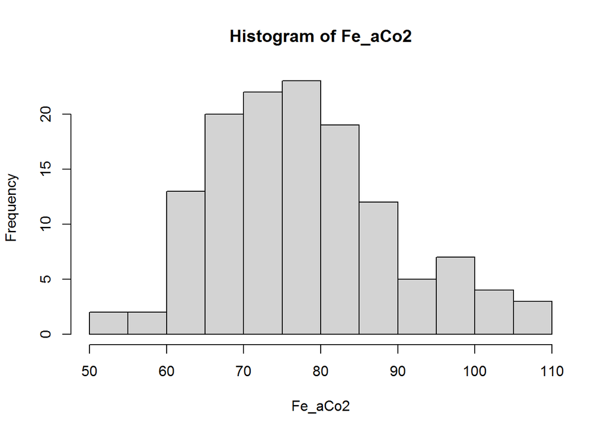

```
## [1] "Test de Shapiro pour la donnée Fe_aCo2"
##
##  Shapiro-Wilk normality test
##
## data:  toua_no_out[, i]
## W = 0.97457, p-value = 0.014
```

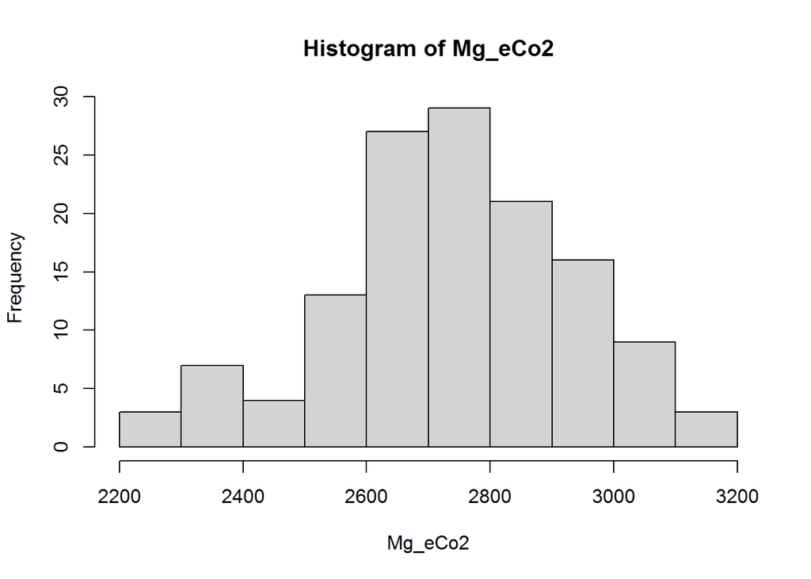

```
## [1] "Test de Shapiro pour la donnée Mg_eCo2"
##
##  Shapiro-Wilk normality test
##
## data:  toua_no_out[, i]
## W = 0.98359, p-value = 0.113
```

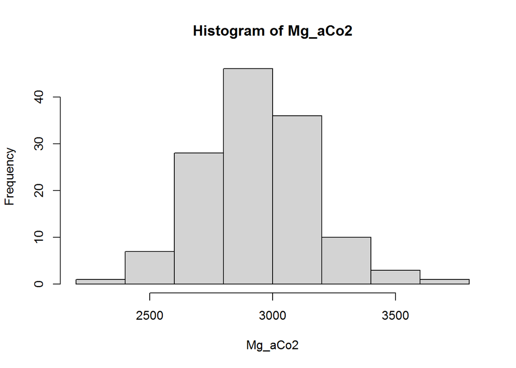

```
## [1] "Test de Shapiro pour la donnée Mg_aCo2"
##
##  Shapiro-Wilk normality test
##
## data:  toua_no_out[, i]
## W = 0.99282, p-value = 0.7421
```

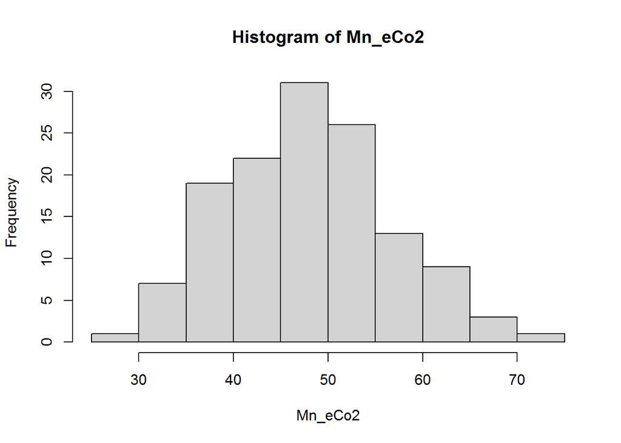

```
## [1] "Test de Shapiro pour la donnée Mn_eCo2"
##
##  Shapiro-Wilk normality test
##
## data:  toua_no_out[, i]
## W = 0.99143, p-value = 0.5999
```

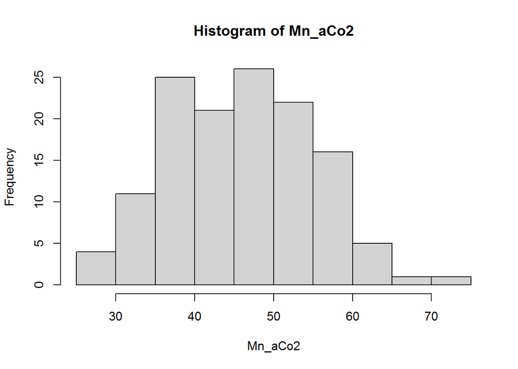

```
## [1] "Test de Shapiro pour la donnée Mn_aCo2"
##
##  Shapiro-Wilk normality test
##
## data:  toua_no_out[, i]
## W = 0.99, p-value = 0.4624
```

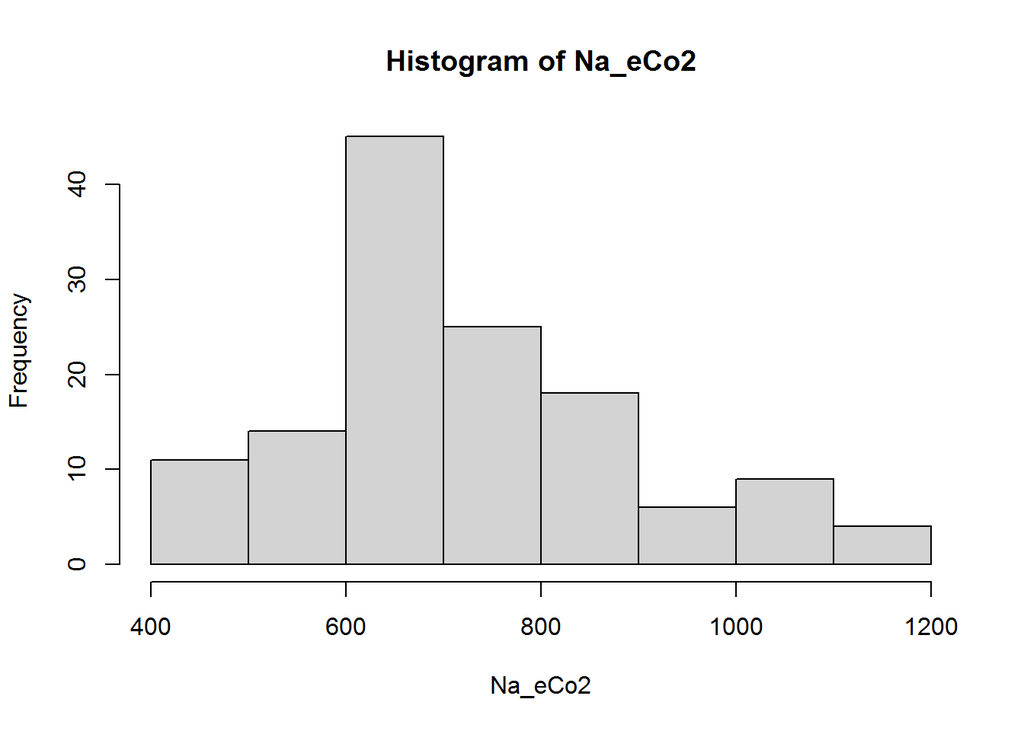

```
## [1] "Test de Shapiro pour la donnée Na_eCo2"
##
##  Shapiro-Wilk normality test
##
## data:  toua_no_out[, i]
## W = 0.94516, p-value = 4.288e-05
```

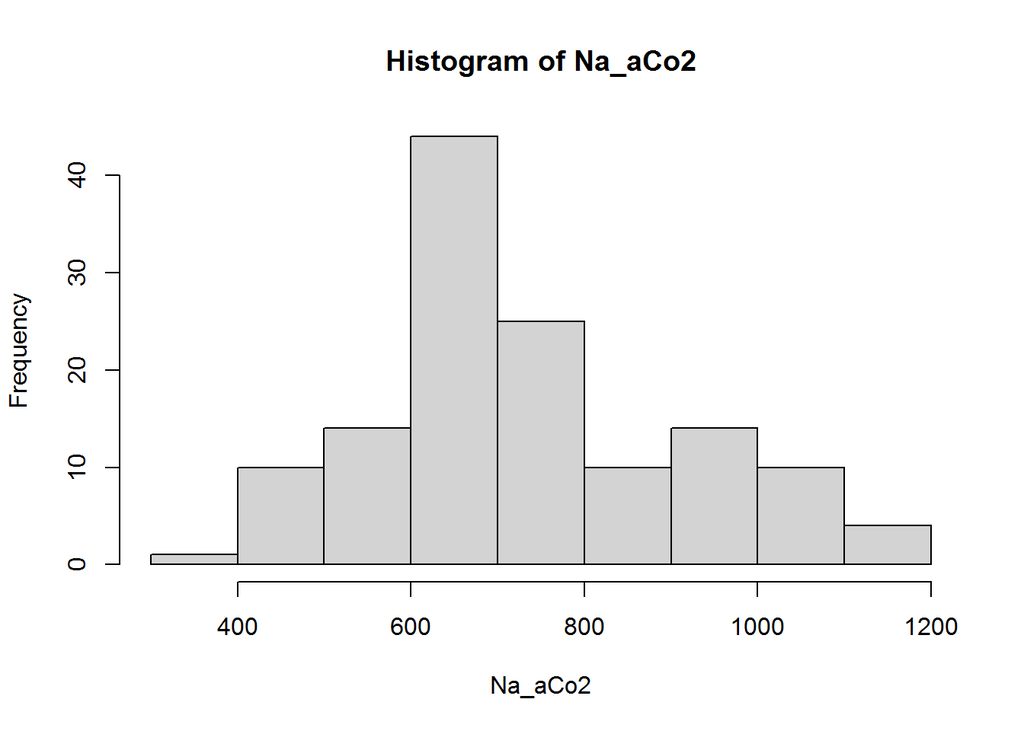

```
## [1] "Test de Shapiro pour la donnée Na_aCo2"
##
##  Shapiro-Wilk normality test
##
## data:  toua_no_out[, i]
## W = 0.95691, p-value = 0.0003561
```

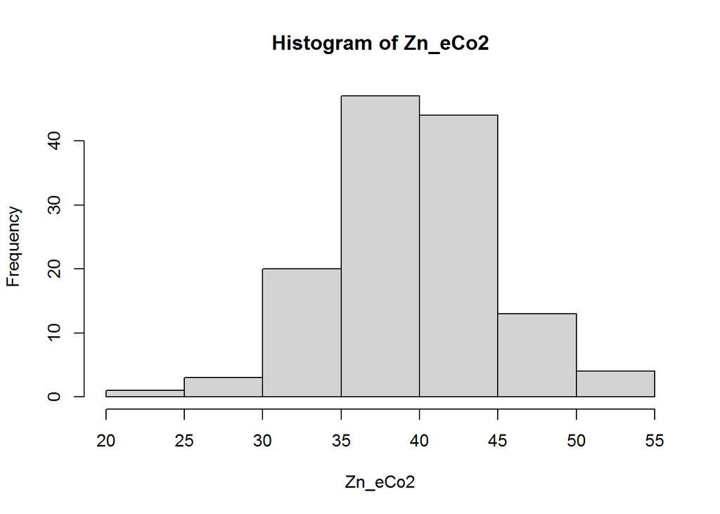

```
## [1] "Test de Shapiro pour la donnée Zn_eCo2"
##
##  Shapiro-Wilk normality test
##
## data:  toua_no_out[, i]
## W = 0.9942, p-value = 0.871
```

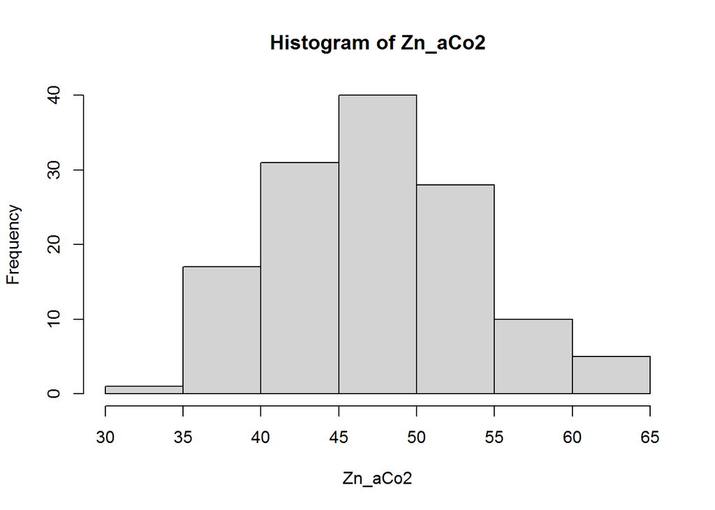

```
## [1] "Test de Shapiro pour la donnée Zn_aCo2"
##
##  Shapiro-Wilk normality test
##
## data:  toua_no_out[, i]
## W = 0.98411, p-value = 0.1277
```

[4 more figures not shown]

```
## [1] "Test de Shapiro pour la donnée N_aCo2"
##
##  Shapiro-Wilk normality test
##
## data:  toua_no_out[, i]
## W = 0.99308, p-value = 0.7683
```

```r
for (i in 2:17) {
  hist(toua_no_out[,i], xlab = names(toua_no_out[i]), main = paste("Histogram of", names(toua_no_out[i])))
  print(paste("Test de Shapiro pour la donnée", names(toua_no_out[i])))
  print(shapiro.test(toua_no_out[,i]))
}
```

### Test de significativité sur les moyennes

Ici on a choisi un test de Wilcoxon ( car on ne respecte pas les pré-requis pour un test paramétrique) pour des valeurs paired, car la mesure en Co2 ambiant et élevé sont réalisés sur les mêmes génotypes.

```
## [1] "Test de Wilcoxon entre les données Cu_eCo2 et Cu_aCo2"
##
##  Wilcoxon signed rank test with continuity correction
##
## data:  toua_no_out[, i + 1] and toua_no_out[, i]
## V = 5986, p-value = 0.0002877
## alternative hypothesis: true location shift is not equal to 0
##
## [1] "Test de Wilcoxon entre les données Fe_eCo2 et Fe_aCo2"
##
##  Wilcoxon signed rank test with continuity correction
##
## data:  toua_no_out[, i + 1] and toua_no_out[, i]
## V = 7508, p-value = 1.411e-12
## alternative hypothesis: true location shift is not equal to 0
##
## [1] "Test de Wilcoxon entre les données Mg_eCo2 et Mg_aCo2"
##
##  Wilcoxon signed rank test with continuity correction
##
## data:  toua_no_out[, i + 1] and toua_no_out[, i]
## V = 7429, p-value = 5.072e-12
## alternative hypothesis: true location shift is not equal to 0
##
## [1] "Test de Wilcoxon entre les données Mn_eCo2 et Mn_aCo2"
##
##  Wilcoxon signed rank test with continuity correction
##
## data:  toua_no_out[, i + 1] and toua_no_out[, i]
## V = 3379.5, p-value = 0.02192
## alternative hypothesis: true location shift is not equal to 0
##
## [1] "Test de Wilcoxon entre les données Na_eCo2 et Na_aCo2"
##
##  Wilcoxon signed rank test with continuity correction
##
## data:  toua_no_out[, i + 1] and toua_no_out[, i]
## V = 4879, p-value = 0.2662
## alternative hypothesis: true location shift is not equal to 0
##
```

[output cut: 8 more lines]

```
## [1] "Test de Wilcoxon entre les données C_eCo2 et C_aCo2"
##
##  Wilcoxon signed rank test with continuity correction
##
## data:  toua_no_out[, i + 1] and toua_no_out[, i]
## V = 4602.5, p-value = 0.6285
## alternative hypothesis: true location shift is not equal to 0
##
## [1] "Test de Wilcoxon entre les données N_eCo2 et N_aCo2"
##
##  Wilcoxon signed rank test with continuity correction
##
## data:  toua_no_out[, i + 1] and toua_no_out[, i]
## V = 8212.5, p-value < 2.2e-16
## alternative hypothesis: true location shift is not equal to 0
```